# Assignment 2 - Patrick Torralba

Author

Patrick Torralba

# Preliminary

```r
library(tidyverse)

stroke <- read_csv("stroke.csv")
```

# Question 1

Define the models

```r
model1 <- glm(
  data = stroke,
  family = binomial,
  stroke ~ heart_disease + hypertension + smoking_status
)

model2 <- glm(
  data = stroke,
  family = binomial,
  stroke ~ heart_disease + hypertension + smoking_status + age + avg_glucose_level + bmi
)
```

Use the models to obtain probabilities

```r
stroke <- stroke |>
  mutate(
    prob1 = predict(model1, type = "response"),
    prob2 = predict(model2, type = "response"),
    ## I also clean the data for future purposes
    stroke1 = case_when(
      stroke == 1 ~ "Stroke",
      stroke == 0 ~ "No Stroke",
      .default = NA)
  )
```

Plots

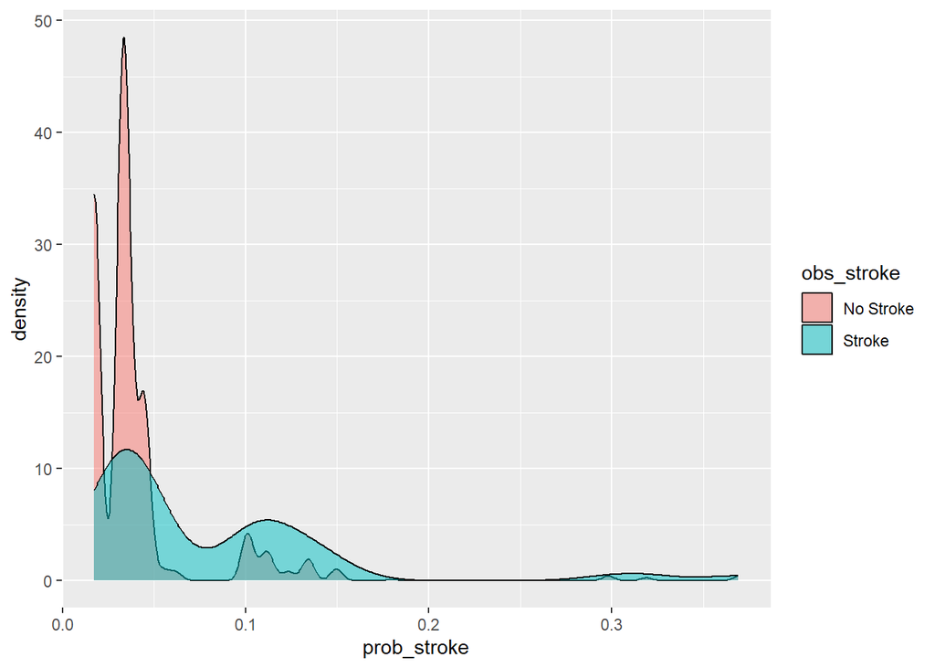

```r
## Model 1 Plot
ggplot(stroke, aes(x = prob1, fill = stroke1)) +
  geom_density(alpha = 0.5) +
  labs(
    x = "prob_stroke",
    fill = "obs_stroke"
  )
```

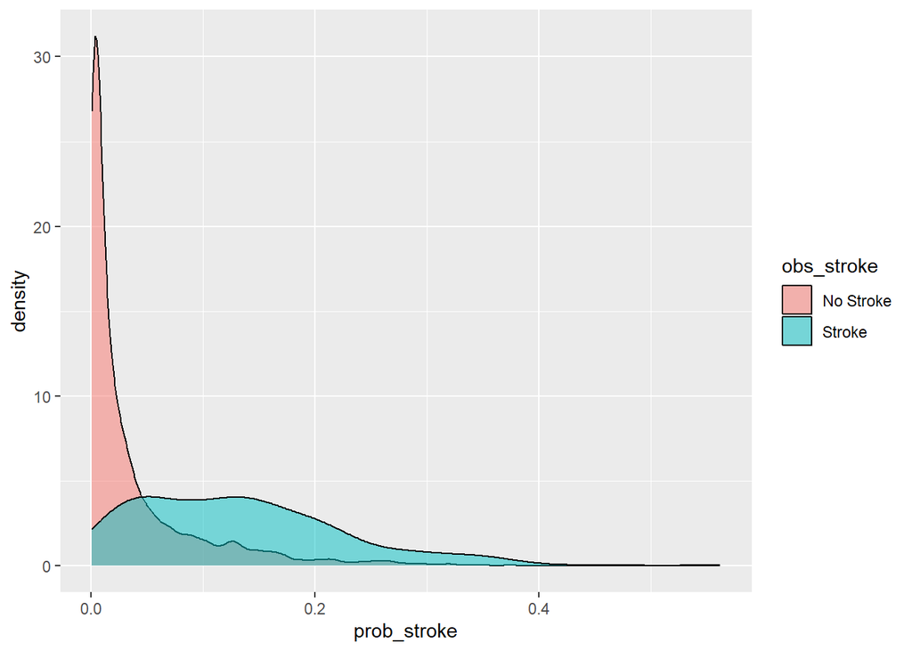

```r
## Model 2 Plot
ggplot(stroke, aes(x = prob2, fill = stroke1)) +
  geom_density(alpha = 0.5) +
  labs(
    x = "prob_stroke",
    fill = "obs_stroke"
  )
```

Table

```r
library(kableExtra)

stroke_table <- stroke |>
  pivot_longer(
    cols = c(prob1, prob2),
    names_to = "Model",
    values_to = "prob_stroke"
  ) |>
  mutate(
    Model = case_when(
      Model == "prob1" ~ "Model 1",
      Model == "prob2" ~ "Model 2",
      .default = NA)
  )|>
  group_by(Model, stroke1) |>
  summarize(
    "Mean prediction" = mean(prob_stroke),
    "Median prediction" = median(prob_stroke),
    "SD prediction" = sd(prob_stroke),
    .groups = "drop"
  ) |>
  rename(`Stroke Observed?` = stroke1)


kable(stroke_table)
```

| Model | Stroke Observed? | Mean prediction | Median prediction | SD prediction |
| --- | --- | --- | --- | --- |
| Model 1 | No Stroke | 0.0409763 | 0.0326098 | 0.0391241 |
| Model 1 | Stroke | 0.0785242 | 0.0444208 | 0.0726425 |
| Model 2 | No Stroke | 0.0385413 | 0.0137576 | 0.0585836 |
| Model 2 | Stroke | 0.1332809 | 0.1254725 | 0.0950056 |

## Answer 1

**It appears that Model 2 is more accurate than Model 1 in terms of predicting stroke outcome. In the summary table, when we look at the median prediction values Model 2 has larger median prediction values than Model 1 for stroke cases only (0.13 vs 0.04, respectively).**

**And, when we look at the density plots, Model 1 has both stroke and no stroke distributions closely overlapping close to zero in contrast to the Model 2 density graph. Therefore, this means that Model 1 is less able to discriminate between stroke outcomes in contrast to Model 2.**

# Question 2

This model includes all covariates except for id and stroke

```r
model3 <- glm(
  data = stroke,
  family = binomial,
  stroke ~ gender + age + hypertension + heart_disease + ever_married + work_type + Residence_type + avg_glucose_level + bmi + smoking_status + stroke
)

stroke_q2 <- stroke |>
  mutate(
    prob3 = predict(model3, type = "response")
  )
```

Model 3 plot

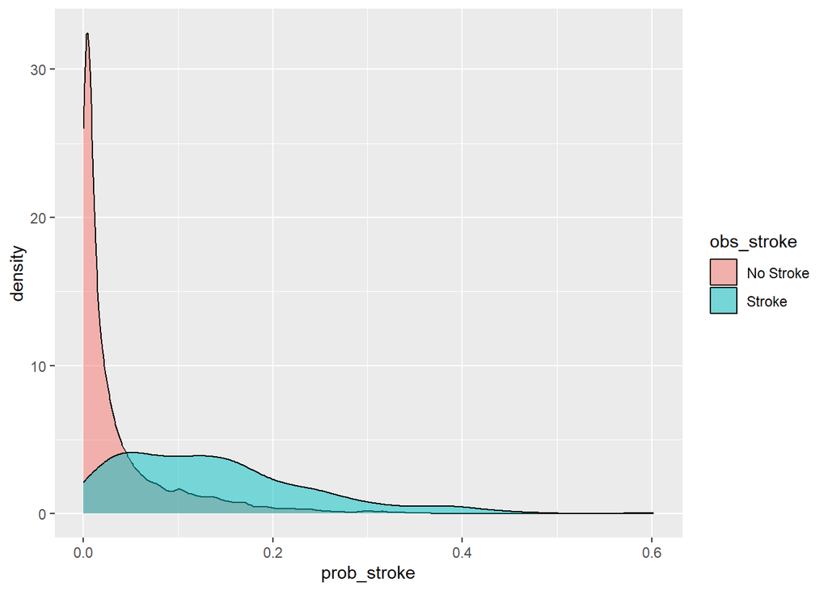

```r
## Model 3 Plot
ggplot(stroke_q2, aes(x = prob3, fill = stroke1)) +
  geom_density(alpha = 0.5) +
  labs(
    x = "prob_stroke",
    fill = "obs_stroke"
  )
```

Model 3 Table

```r
stroke_table_q2 <- stroke_q2 |>
  pivot_longer(
    cols = c(prob1, prob2, prob3),
    names_to = "Model",
    values_to = "prob_stroke"
  ) |>
  mutate(
    Model = case_when(
      Model == "prob1" ~ "Model 1",
      Model == "prob2" ~ "Model 2",
      Model == "prob3" ~ "Model 3",
      .default = NA)
  )|>
  group_by(Model, stroke1) |>
  summarize(
    "Mean prediction" = mean(prob_stroke),
    "Median prediction" = median(prob_stroke),
    "SD prediction" = sd(prob_stroke),
    .groups = "drop"
  ) |>
  rename(`Stroke Observed?` = stroke1)


kable(stroke_table_q2)
```

| Model | Stroke Observed? | Mean prediction | Median prediction | SD prediction |
| --- | --- | --- | --- | --- |
| Model 1 | No Stroke | 0.0409763 | 0.0326098 | 0.0391241 |
| Model 1 | Stroke | 0.0785242 | 0.0444208 | 0.0726425 |
| Model 2 | No Stroke | 0.0385413 | 0.0137576 | 0.0585836 |
| Model 2 | Stroke | 0.1332809 | 0.1254725 | 0.0950056 |
| Model 3 | No Stroke | 0.0383467 | 0.0129303 | 0.0590130 |
| Model 3 | Stroke | 0.1376579 | 0.1209023 | 0.1034864 |

## Answer 2

**No, adding more variables does not appear to improve stroke prediction. Model 3 does have a slightly higher mean prediction (0.14 vs 0.13), but Model 3 also has a lower median stroke prediction value (0.12 vs 0.13, respectively).**

**Likewise, when we compare the density graphs, both Model 3 and Model 2 plots look extremely identical.**

**Therefore, the table and graph mean that adding more variables do not improve stroke prediction outcome. Although the differences between Model 3 and Model 2 appear minimal..**

# Question 3

```r
stroke_q3 <- stroke_q2 |>
  mutate(
    Age = case_when(
      age > 50 ~ "Age > 50",
      .default = "Age <= 50"
    )
  )
```

Plot

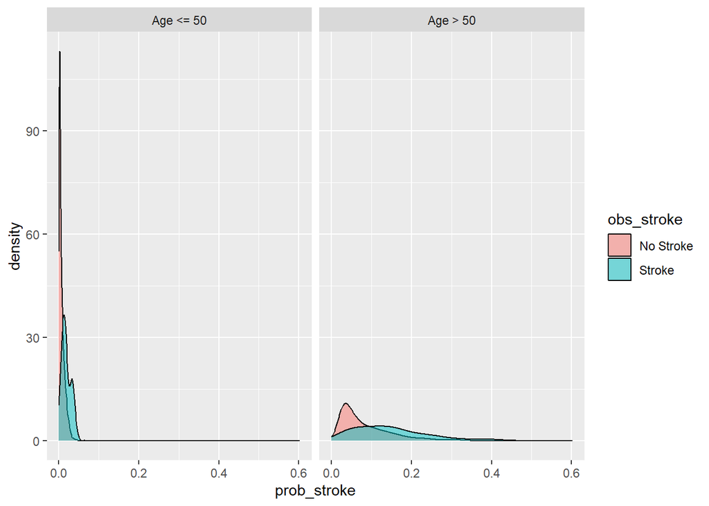

```r
ggplot(stroke_q3, aes(x = prob3, fill = stroke1)) +
  geom_density(alpha = 0.5) +
  facet_wrap(~ Age) +
  labs(
    x = "prob_stroke",
    fill = "obs_stroke"
  )
```

Table

```r
stroke_table_q3 <- stroke_q3 |>
  group_by(Age, stroke1) |>
  select(-prob1, -prob2) |>
  summarize(
    "Mean prediction" = mean(prob3),
    "Median prediction" = median(prob3),
    "SD prediction" = sd(prob3),
    .groups = "drop"
  ) |>
  rename(`Stroke Observed?` = stroke1)


kable(stroke_table_q3)
```

| Age | Stroke Observed? | Mean prediction | Median prediction | SD prediction |
| --- | --- | --- | --- | --- |
| Age <= 50 | No Stroke | 0.0074680 | 0.0047535 | 0.0076925 |
| Age <= 50 | Stroke | 0.0185263 | 0.0162496 | 0.0111279 |
| Age > 50 | No Stroke | 0.0871659 | 0.0623829 | 0.0707456 |
| Age > 50 | Stroke | 0.1509651 | 0.1361316 | 0.1006331 |

## Answer 3

**It appears that Model 3 is better at predicting stroke for older individuals because when we look at the Age > 50 plot, there isn’t as much overlap in contrast to Age <= 50 density plot. This means that Model 3 is better able to discriminate stroke outcomes for older individuals.**

**Also when we look at the summary table, younger people with strokes have both a mean and median prediction values significantly lower their older people counterparts (0.02 and 0.02 vs 0.15 and 0.14, respectively).**

# Question 4

```r
cutpoints <- c(11, 21, 31, 41, 51)

q4 <- map_dfr(cutpoints, ~ tibble(
  `Cutpoint` = .x,
  `Age Group` = c(
    str_c(.x, ">"),
    str_c("<=",.x)),
  `N in group` = c(
    sum(stroke$age > .x),
    sum(stroke$age <= .x)),
  `Prob of stroke` = c(
    mean(stroke$stroke[stroke$age > .x], na.rm = TRUE),
    mean(stroke$stroke[stroke$age <= .x], na.rm = TRUE)
  )
))

kable(q4)
```

| Cutpoint | Age Group | N in group | Prob of stroke |
| --- | --- | --- | --- |
| 11 | 11> | 4380 | 0.0477169 |
| 11 | <=11 | 529 | 0.0000000 |
| 21 | 21> | 3862 | 0.0538581 |
| 21 | <=21 | 1047 | 0.0009551 |
| 31 | 31> | 3298 | 0.0630685 |
| 31 | <=31 | 1611 | 0.0006207 |
| 41 | 41> | 2654 | 0.0764883 |
| 41 | <=41 | 2255 | 0.0026608 |
| 51 | 51> | 1926 | 0.0960540 |
| 51 | <=51 | 2983 | 0.0080456 |

```r
diff_summary <- q4 |>
  group_by(Cutpoint) |>
  summarize(
    Prob_Greater = `Prob of stroke`[1],  # 1st row is >
    Prob_Less    = `Prob of stroke`[2],  # 2nd row is <=
    Difference   = abs(Prob_Greater - Prob_Less),
    .groups = "drop"
  ) |>
  arrange(desc(Difference))

kable(diff_summary)
```

| Cutpoint | Prob_Greater | Prob_Less | Difference |
| --- | --- | --- | --- |
| 51 | 0.0960540 | 0.0080456 | 0.0880084 |
| 41 | 0.0764883 | 0.0026608 | 0.0738276 |
| 31 | 0.0630685 | 0.0006207 | 0.0624478 |
| 21 | 0.0538581 | 0.0009551 | 0.0529030 |
| 11 | 0.0477169 | 0.0000000 | 0.0477169 |

## Answer 4

**The largest difference in stroke probability between partitions is the equal or over age 51 group.**

**Specifically, >= 51 group has a stroke difference of probability of 0.09**

# Question 5

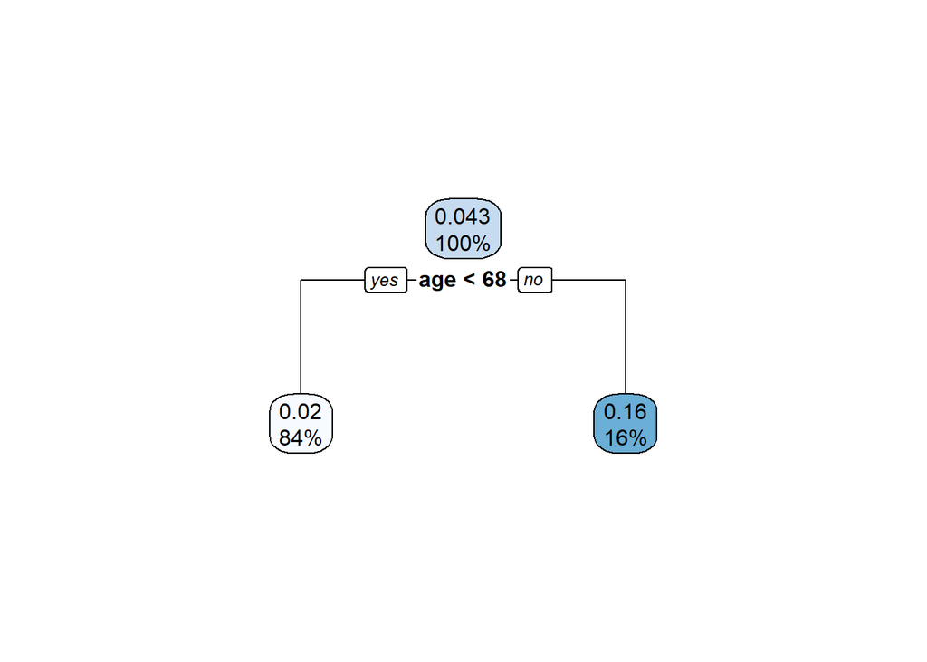

```r
library(rpart)
library(rpart.plot)

stroke_tree <- rpart(stroke ~ gender + age + hypertension + heart_disease + ever_married + work_type + Residence_type + avg_glucose_level + bmi + smoking_status, data = stroke)

rpart.plot(stroke_tree)
```

```r
pred_stroke <- predict(stroke_tree)

unique(pred_stroke)
```

```
[1] 0.02039825 0.15802781
```

Plot

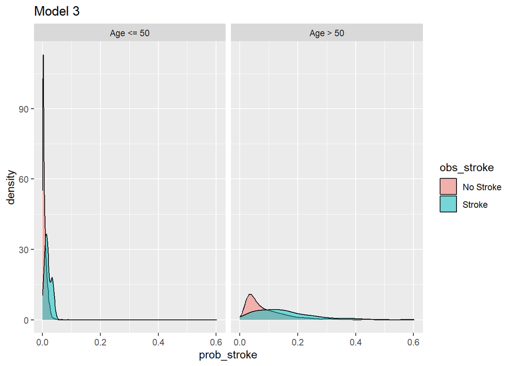

```r
stroke_q5 <- stroke |>
  mutate(
    Age = case_when(
      age < 68 ~ "Age < 68",
      .default = "Age >= 68"),
    prob5 = predict(stroke_tree)
  )

ggplot(stroke_q3, aes(x = prob3, fill = stroke1)) +
  geom_density(alpha = 0.5) +
  facet_wrap(~ Age) +
  labs(
    x = "prob_stroke",
    fill = "obs_stroke",
    title = "Model 3"
  )
```

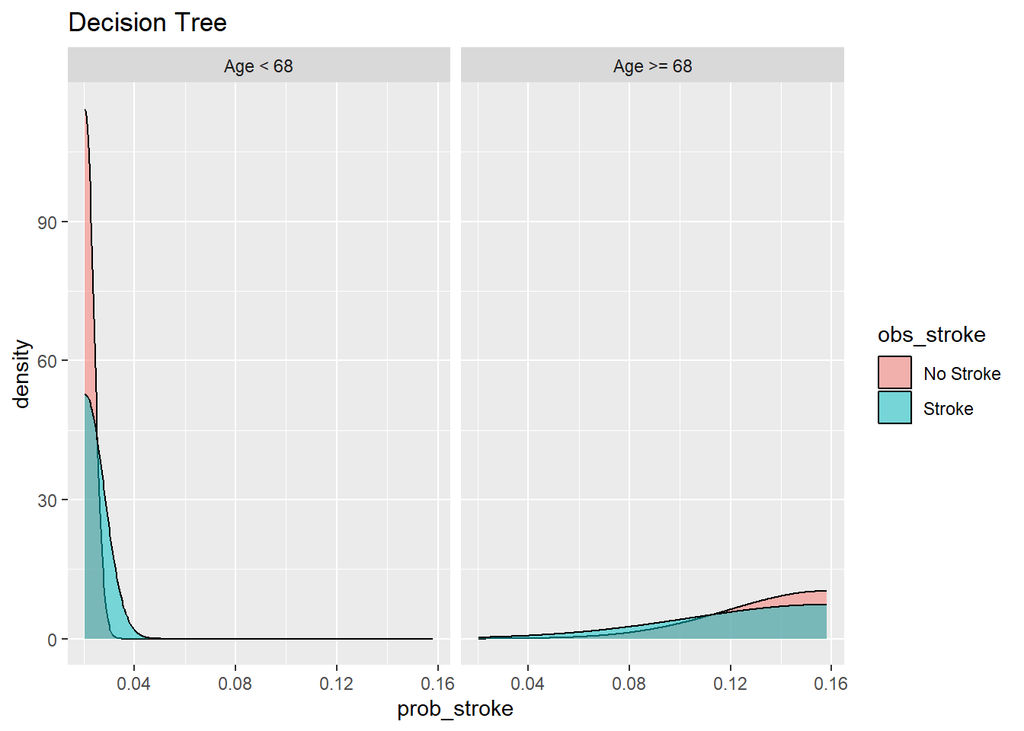

```r
ggplot(stroke_q5, aes(x = prob5, fill = stroke1)) +
  geom_density(alpha = 0.5) +
  facet_wrap(~ Age) +
  labs(
    x = "prob_stroke",
    fill = "obs_stroke",
    title = "Decision Tree"
  )
```

Table

```r
stroke_table_q5 <- stroke_q5 |>
  group_by(Age, stroke1) |>
  select(-prob1, -prob2) |>
  summarize(
    "Mean prediction" = mean(prob5),
    "Median prediction" = median(prob5),
    "SD prediction" = sd(prob5),
    .groups = "drop"
  ) |>
  rename(`Stroke Observed?` = stroke1)


kable(stroke_table_q3, caption = "Model 3")
```

Model 3

| Age | Stroke Observed? | Mean prediction | Median prediction | SD prediction |
| --- | --- | --- | --- | --- |
| Age <= 50 | No Stroke | 0.0074680 | 0.0047535 | 0.0076925 |
| Age <= 50 | Stroke | 0.0185263 | 0.0162496 | 0.0111279 |
| Age > 50 | No Stroke | 0.0871659 | 0.0623829 | 0.0707456 |
| Age > 50 | Stroke | 0.1509651 | 0.1361316 | 0.1006331 |

```r
kable(stroke_table_q5, caption = "Decision Tree")
```

Decision Tree

| Age | Stroke Observed? | Mean prediction | Median prediction | SD prediction |
| --- | --- | --- | --- | --- |
| Age < 68 | No Stroke | 0.0203983 | 0.0203983 | 0 |
| Age < 68 | Stroke | 0.0203983 | 0.0203983 | 0 |
| Age >= 68 | No Stroke | 0.1580278 | 0.1580278 | 0 |
| Age >= 68 | Stroke | 0.1580278 | 0.1580278 | 0 |

## Answer 5

**There are only two unique values for the decision tree because these two values represent probabilities of developing a stroke under the condition that the individual is over or under the age of 68. Essentially, we do not have any more unique values because we do not have any more leaf nodes.**

**The decision tree isn’t any more accurate in predicting stroke in contrast to the logistic regression model. When we compare the median stroke prediction values between Model 3 and the decision tree for older individuals we get 0.13 and 0.16, respectively; for younger individuals we get median stroke prediction values of 0.02 and 0.02, respectively. Essentially, these values tell us that both models are very similar in predicting stroke outcome.**

**And, when we compare density plots, both plots appear similar with younger individuals highly overlapping and older individuals being more distinguishable. However, the decision tree plot has stroke probabilities that are much closer to zero. Another difference is that for older individuals, the stroke probabilities have higher overlap.**

**Therefore, Model 3 is more accurate in predicting stroke in comparison to the decision tree model**